# R Notebook

When comparing the win percentages and the popularity scores for each team, we can see that there is somewhat of an association between win percentage and search popularity. The teams with the top 3 win percentages since 2004 which are the San Antonio Spurs, the Oklahoma City Thunder, and the Dallas Mavericks, are also within the top 11 for mean popularity score. This may seem to indicate that teams that have higher win percentages are likely to have higher popularity scores.

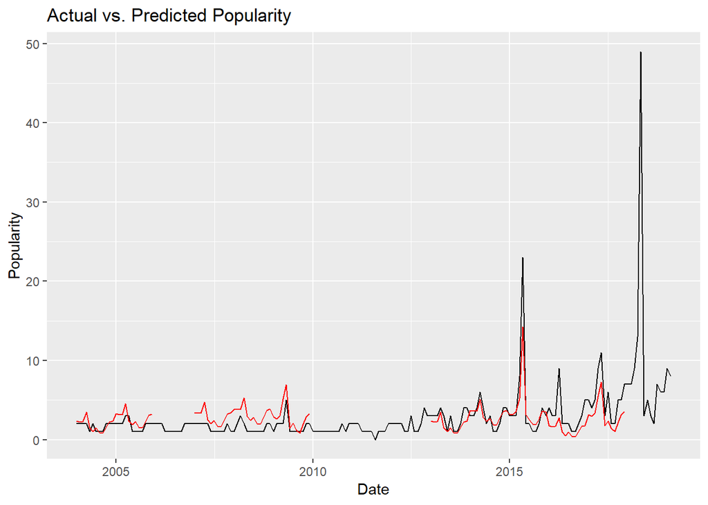

```r
## Need to combine observations like "made semis"
## Blanks -> No, did not make semis

NBATeams <- NBATeams %>% add_predictions(seasondata_model)

NBATeams %>%
  filter(Team == "HoustonRockets") %>%
  ggplot() + geom_line(aes(x = Date, y = Popularity)) + geom_line(aes(x = Date, y = pred), col = "red") +
  ggtitle("Actual vs. Predicted Popularity")
```

```r
## KB - mixed
```

```r
#Setting all blank values of Playoffs variable to be of type N/A
is.na(NBATeams$Playoffs) <- which(NBATeams$Playoffs == "")

#Setting all N/A observations of Playoffs variable to read as "Did Not Make #Playoffs"
NBATeams$Playoffs[is.na(NBATeams$Playoffs)] <- "Did Not Make Playoffs"

#Renaming Playoffs values to combine East/West
NBATeams$Playoffs<- as.character(NBATeams$Playoffs)

#Renaming Western Conference Finals
NBATeams$Playoffs[NBATeams$Playoffs == "Lost W. Conf. Finals"] <- "Lost Conf. Finals"

#Renaming Eastern Conference Finals
NBATeams$Playoffs[NBATeams$Playoffs == "Lost E. Conf. Finals"] <- "Lost Conf. Finals"

#Renaming Eastern Conference Semis
NBATeams$Playoffs[NBATeams$Playoffs == "Lost E. Conf. Semis"] <- "Lost Conf. Semis"

#Renaming Western Conference Semis
NBATeams$Playoffs[NBATeams$Playoffs == "Lost W. Conf. Semis"] <- "Lost Conf. Semis"

#Renaming Eastern Conference 1st Round
NBATeams$Playoffs[NBATeams$Playoffs == "Lost E. Conf. 1st Rnd."] <- "Lost 1st Round"

#Renaming Western Conference 1st Round
NBATeams$Playoffs[NBATeams$Playoffs == "Lost W. Conf. 1st Rnd."] <- "Lost 1st Round"

#Setting Playoffs variable to be a factor again
NBATeams$Playoffs <- as.factor(NBATeams$Playoffs)

#Checking levels of Playoff variable to ensure only 6 possible levels
levels(NBATeams$Playoffs)
```

```
## [1] "Did Not Make Playoffs" "Lost 1st Round"        "Lost Conf. Finals"
## [4] "Lost Conf. Semis"      "Lost Finals"           "Won Finals"
```

```r
seasondata_model <- lm(Popularity ~ Team + factor(MonthNum):(W.L. + Playoffs)
                       , data = NBATeams)
summary(seasondata_model)
```

```
##
## Call:
## lm(formula = Popularity ~ Team + factor(MonthNum):(W.L. + Playoffs),
##     data = NBATeams)
##
## Residuals:
##     Min      1Q  Median      3Q     Max
## -24.958  -1.156  -0.105   0.803  66.849
##
## Coefficients:
##                                               Estimate Std. Error t value
## (Intercept)                                  -2.208611   0.363285  -6.080
## TeamBostonCeltics                             2.233022   0.400551   5.575
## TeamBrooklynNets                              0.764562   0.525719   1.454
## TeamCharlotteHornets                         -0.301294   0.615811  -0.489
## TeamChicagoBulls                              2.347392   0.398705   5.888
## TeamClevelandCavaliers                        3.563354   0.406366   8.769
## TeamDallasMavericks                          -0.483350   0.404679  -1.194
## TeamDenverNuggets                            -0.919100   0.404445  -2.272
## TeamDetroitPistons                           -0.807154   0.403601  -2.000
## TeamGoldenStateWarriors                       4.357216   0.408695  10.661
## TeamHoustonRockets                            0.408893   0.405858   1.007
## TeamIndianaPacers                            -0.664644   0.400188  -1.661
## TeamLosAngelesClippers                        0.004453   0.399992   0.011
## TeamLosAngelesLakers                          5.594662   0.402756  13.891
## TeamMemphisGrizzlies                         -0.924392   0.398450  -2.320
## TeamMiamiHeat                                 1.165728   0.406376   2.869
## TeamMilwaukeeBucks                            0.212315   0.400417   0.530
## TeamMinnesotaTimberwolves                    -0.403737   0.404382  -0.998
## TeamNewOrleansPelicans                       -0.489401   0.566817  -0.863
## TeamNewYorkKnicks                             2.356408   0.400423   5.885
## TeamOklahomaCityThunder                       0.808076   0.453136   1.783
## TeamOrlandoMagic                             -0.872867   0.399971  -2.182
## TeamPhiladelphia76ers                         0.714108   0.399404   1.788
## TeamPhoenixSuns                              -0.677197   0.405519  -1.670
## TeamPortlandTrailBlazers                     -0.391837   0.400941  -0.977
## TeamSacramentoKings                          -0.109255   0.401193  -0.272
## TeamSanAntonioSpurs                          -0.599354   0.415094  -1.444
## TeamTorontoRaptors                           -1.212735   0.401353  -3.022
## TeamUtahJazz                                 -0.941889   0.402083  -2.343
```

[output cut: 168 more lines]

```
## factor(MonthNum)5:PlayoffsWon Finals         5.25e-14 ***
## factor(MonthNum)6:PlayoffsWon Finals          < 2e-16 ***
## factor(MonthNum)7:PlayoffsWon Finals         0.086833 .
## factor(MonthNum)8:PlayoffsWon Finals         0.041855 *
## factor(MonthNum)9:PlayoffsWon Finals         0.052305 .
## factor(MonthNum)10:PlayoffsWon Finals        0.156326
## factor(MonthNum)11:PlayoffsWon Finals        0.640211
## factor(MonthNum)12:PlayoffsWon Finals        0.244978
## ---
## Signif. codes:  0 '***' 0.001 '**' 0.01 '*' 0.05 '.' 0.1 ' ' 1
##
## Residual standard error: 3.765 on 4878 degrees of freedom
##   (480 observations deleted due to missingness)
## Multiple R-squared:  0.4557, Adjusted R-squared:  0.4445
## F-statistic: 40.44 on 101 and 4878 DF,  p-value: < 2.2e-16
```

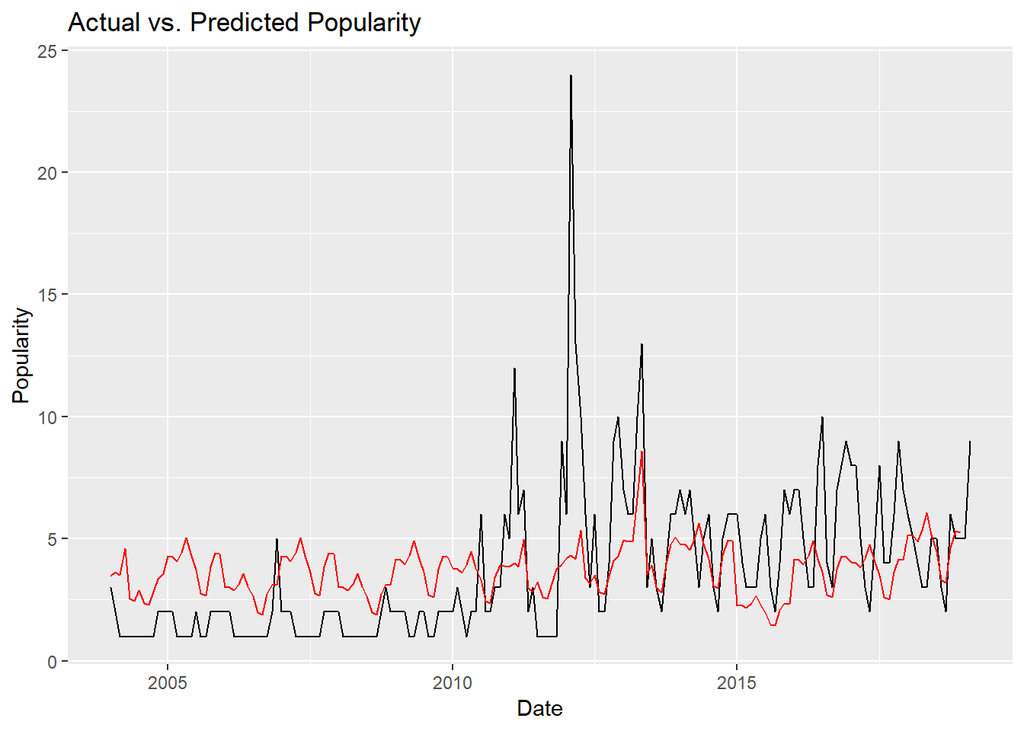

```r
NBATeams <- NBATeams %>% add_predictions(seasondata_model)

NBATeams %>%
  filter(Team == "NewYorkKnicks") %>%
  ggplot() + geom_line(aes(x = Date, y = Popularity)) + geom_line(aes(x = Date, y = pred), col = "red") +
  ggtitle("Actual vs. Predicted Popularity")
```

## Bandwagony

```r
NBATeams %>%
  filter(Team == "GoldenStateWarriors") %>%
  dplyr::select(Playoffs, pred, Popularity, W.L., MonthNum) %>%
  group_by(Playoffs) %>%
  summarize(Bandwagon = mean(Popularity, na.rm = TRUE) - mean(pred, na.rm = TRUE))
```

| Playoffs | Bandwagon |
| --- | --- |
| Did Not Make Playoffs | -2.411836 |
| Lost 1st Round | -2.619458 |
| Lost Conf. Semis | -2.463345 |
| Lost Finals | 20.038998 |
| Won Finals | 5.721230 |

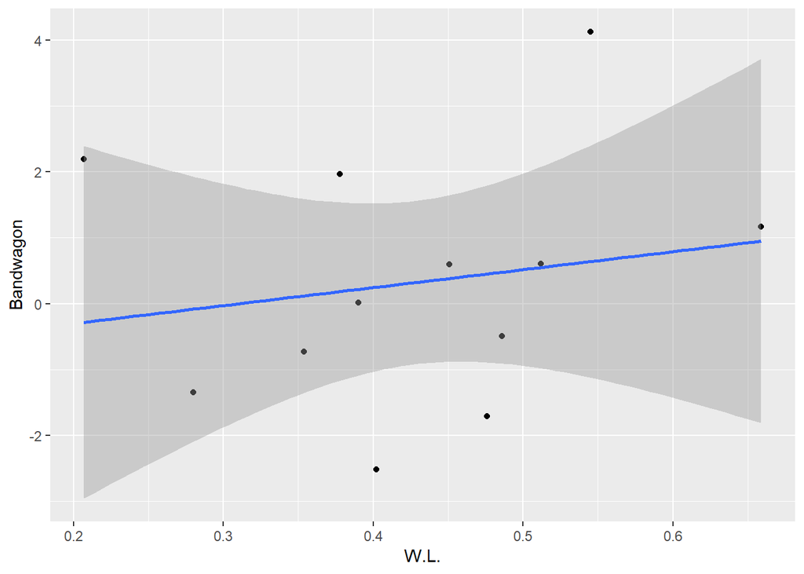

```r
NBATeams %>%
  filter(Team == "NewYorkKnicks") %>%
  dplyr::select(pred, Popularity, W.L.) %>%
  group_by(W.L.) %>%
  summarize(Bandwagon = mean(Popularity, na.rm = TRUE) - mean(pred, na.rm = TRUE)) %>%
  ggplot(aes(x = W.L., y = Bandwagon)) + geom_point() + stat_smooth(method = "lm")
```

- most to least bandwagony teams
- data from regions specifically, balance by TV market size?
- nice plots by Victor
- Market size/TV market into data, explore at will

```r
#Reading in NBA Market Dataset obtained from #https://www.sportsmediawatch.com/nba-market-size-nfl-mlb-nhl-nielsen-ratings/

NBAMarket <- read.csv("NBAMarketSize.csv", header = TRUE)
#Contains data on television market size, as defined by Nielsen market size.
```

Note: Toronto is not included in this dataset since Nielsen only tracks data for cities in the United States. Need to decide how to account for this, since our data from Google Trends only includes searches in the United States, but the Raptors play in Toronto. Include them with New York??

```r
NBATeams %>%
  dplyr::select(Playoffs, pred, Popularity, W.L., MonthNum, Team) %>%
  group_by(Team, Playoffs == "Did Not Make Playoffs") %>%
  summarize(Bandwagon = mean(Popularity, na.rm = TRUE) - mean(pred, na.rm = TRUE)) #%>% arrange(-Bandwagon)
```

| Team | Playoffs == "Did Not Make Playoffs" | Bandwagon |
| --- | --- | --- |
| AtlantaHawks | FALSE | -0.192154724 |
| AtlantaHawks | TRUE | 0.418180416 |
| BostonCeltics | FALSE | -0.153250310 |
| BostonCeltics | TRUE | 0.675605018 |
| BrooklynNets | FALSE | -0.091715195 |
| BrooklynNets | TRUE | -0.051359386 |
| CharlotteHornets | FALSE | 0.228805659 |
| CharlotteHornets | TRUE | -0.193588814 |
| ChicagoBulls | FALSE | 0.201280963 |
| ChicagoBulls | TRUE | -0.507689316 |

[output cut: 50 more lines]

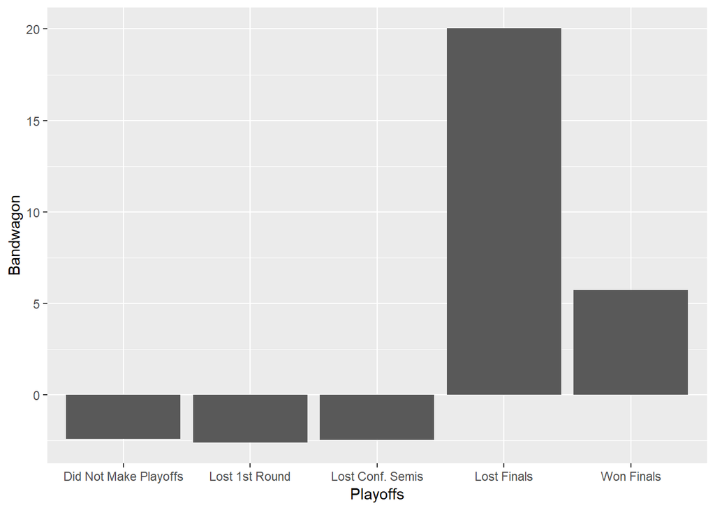

```r
bw <- NBATeams %>%
  dplyr::select(Playoffs, pred, Popularity, W.L., MonthNum, Team) %>%
  group_by(Team, Playoffs) %>%
  summarize(Bandwagon = mean(Popularity, na.rm = TRUE) - mean(pred, na.rm = TRUE))

bw %>% filter(Team == "GoldenStateWarriors") %>%
  ggplot(aes(x = Playoffs, y = Bandwagon)) + geom_col()
```

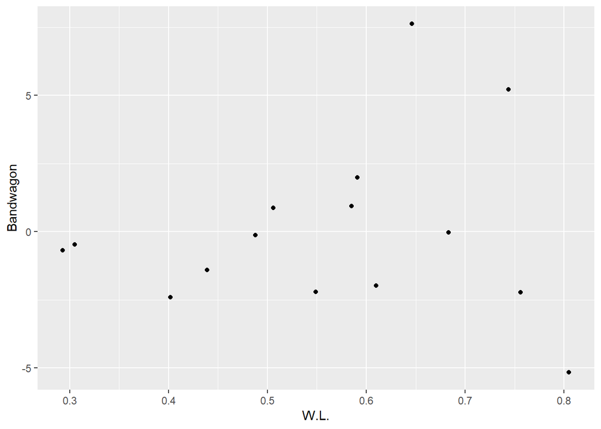

```r
NBATeams %>%
  dplyr::select(Playoffs, pred, Popularity, W.L., MonthNum, Team, Season) %>%
  group_by(Season, Team) %>%
  summarize(Bandwagon = mean(Popularity, na.rm = TRUE) - mean(pred, na.rm = TRUE),
            W.L. = mean(W.L.)) %>%
  filter(Team == "BostonCeltics") %>%
  ggplot(aes(x = W.L., y = Bandwagon)) + geom_point()
```

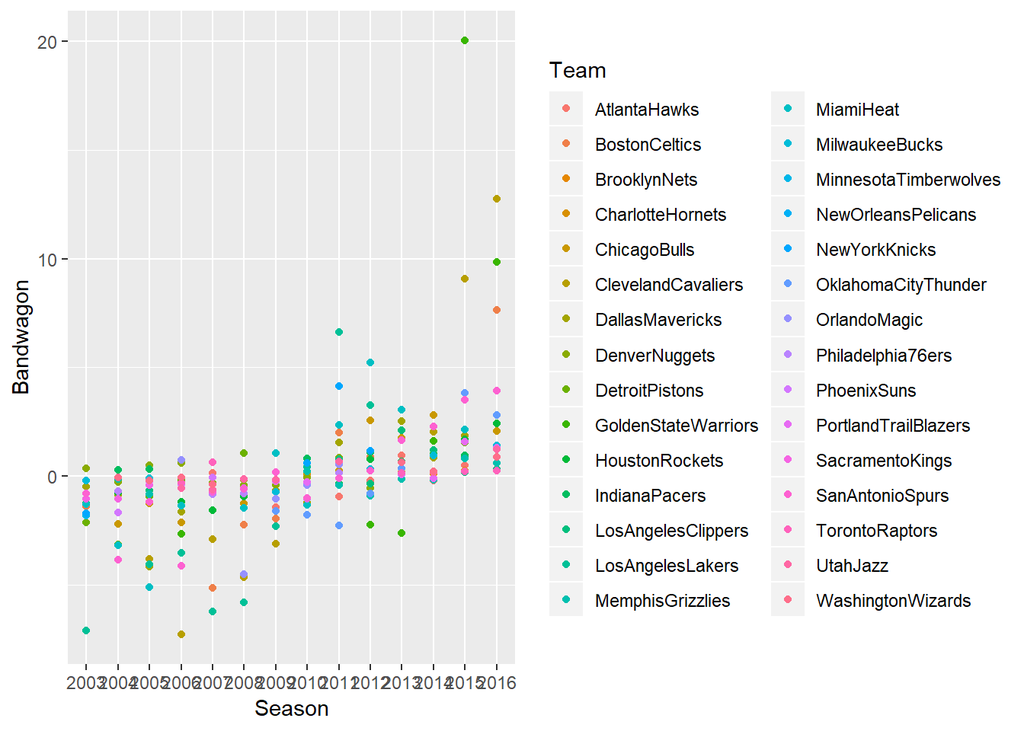

```r
NBATeams %>% filter(Playoffs != "Did Not Make Playoffs") %>%
  group_by(Team, Season) %>%
  summarize(Bandwagon = mean(Popularity, na.rm = TRUE) - mean(pred, na.rm = TRUE)) %>%
  ggplot(aes(x = Season, y = Bandwagon, col = Team)) +
  geom_point()
```

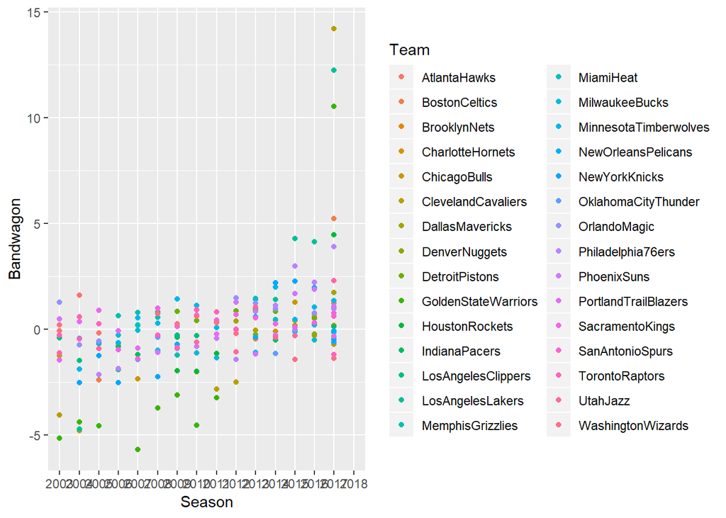

```r
NBATeams %>%
  filter(Playoffs == "Did Not Make Playoffs") %>%
  group_by(Team, Season) %>%
  summarize(Bandwagon = mean(Popularity, na.rm = TRUE) - mean(pred, na.rm = TRUE)) %>%
  ggplot(aes(x = Season, y = Bandwagon, col = Team)) +
  geom_point()
```

```r
#Computing Bandwagon Score for years in which team did not make pos
NBATeams %>% filter(Playoffs == "Did Not Make Playoffs") %>%
  group_by(Team) %>%
  summarize(Bandwagon = mean(Popularity, na.rm = TRUE) - mean(pred, na.rm = TRUE))
```

| Team | Bandwagon |
| --- | --- |
| AtlantaHawks | 0.418180416 |
| BostonCeltics | 0.675605018 |
| BrooklynNets | -0.051359386 |
| CharlotteHornets | -0.193588814 |
| ChicagoBulls | -0.507689316 |
| ClevelandCavaliers | -0.315897808 |
| DallasMavericks | 1.097383909 |
| DenverNuggets | 0.041790491 |
| DetroitPistons | 0.612814010 |
| GoldenStateWarriors | -2.411835762 |

[output cut: 20 more lines]

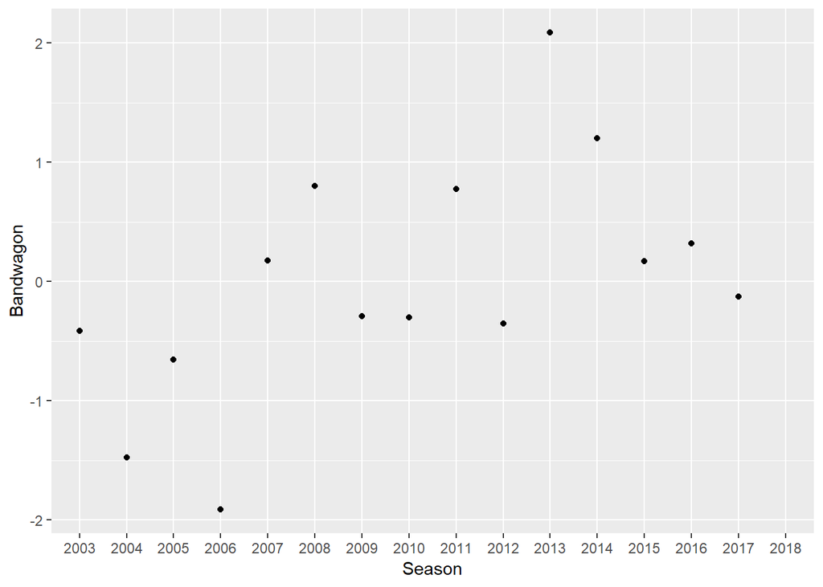

```r
NBATeams %>%
  group_by(Team, Season) %>%
  summarize(Bandwagon = mean(Popularity, na.rm = TRUE) - mean(pred, na.rm = TRUE)) %>%
  filter(Team == "LosAngelesClippers") %>%
  ggplot(aes(x = Season, y = Bandwagon)) + geom_point()
```

```r
#Computing Bandwagon Score for years in which team made playoffs
bw_Playoffs <- NBATeams %>% filter(Playoffs != "Did Not Make Playoffs") %>%
  group_by(Team) %>%
  summarize(Bandwagon = mean(Popularity, na.rm = TRUE) - mean(pred, na.rm = TRUE))
```

```r
#Computing Bandwagon Score for years in which team did not make playoffs
bw_NoPlayoffs <- NBATeams %>% filter(Playoffs == "Did Not Make Playoffs") %>%
  group_by(Team) %>%
  summarize(Bandwagon = mean(Popularity, na.rm = TRUE) - mean(pred, na.rm = TRUE))
```

```r
bw_Overall<- bw_NoPlayoffs %>% dplyr::select(Team)
bw_Overall$Playoffs <- bw_Playoffs$Bandwagon
bw_Overall$NoPlayoffs <- bw_NoPlayoffs$Bandwagon
bw_Overall$Bandwagon <- bw_Overall$Playoffs - bw_Overall$NoPlayoffs

bw_Overall %>% arrange(desc(Bandwagon))
```

| Team | Playoffs | NoPlayoffs | Bandwagon |
| --- | --- | --- | --- |
| GoldenStateWarriors | 3.989218290 | -2.411835762 | 6.40105405 |
| OklahomaCityThunder | 0.067631779 | -1.771186169 | 1.83881795 |
| NewYorkKnicks | 1.045930947 | -0.324933732 | 1.37086468 |
| IndianaPacers | 0.422372361 | -0.587762745 | 1.01013511 |
| NewOrleansPelicans | 0.180367564 | -0.767150715 | 0.94751828 |
| LosAngelesClippers | 0.506307165 | -0.411131015 | 0.91743818 |
| ChicagoBulls | 0.201280963 | -0.507689316 | 0.70897028 |
| ClevelandCavaliers | 0.255819497 | -0.315897808 | 0.57171731 |
| PortlandTrailBlazers | 0.253468735 | -0.184795347 | 0.43826408 |
| CharlotteHornets | 0.228805659 | -0.193588814 | 0.42239447 |

[output cut: 20 more lines]

- statistical tests for pop. disc. differences for:
- PO vs not
- W.L.
- more categories - didn’t make POs vs. 1st round etc
- Bandwagon metrics correlate to:
- overall popularity of team
- overall success of team
- other confounders
- Incorporating other datasets

```r
#Testing differences of Popularity scores across Playoff categories
PlayoffsAnova <- lm(Popularity~Playoffs, data=NBATeams)
anova(PlayoffsAnova)
```

|  | Df | Sum Sq | Mean Sq | F value | Pr(>F) |
| --- | --- | --- | --- | --- | --- |
| Playoffs | 5 | 14980.15 | 2996.02976 | 140.2074 | 2.552674e-140 |
| Residuals | 5454 | 116544.15 | 21.36856 | NA | NA |

```r
aov.fit1 <- aov(Popularity ~ Playoffs, data=NBATeams)
posthoc <- TukeyHSD(x=aov.fit1, conf.level=0.95)
posthoc
```

```
##   Tukey multiple comparisons of means
##     95% family-wise confidence level
##
## Fit: aov(formula = Popularity ~ Playoffs, data = NBATeams)
##
## $Playoffs
##                                                 diff        lwr       upr
## Lost 1st Round-Did Not Make Playoffs     0.006224336 -0.4368543 0.4493029
## Lost Conf. Finals-Did Not Make Playoffs  1.394308343  0.6349497 2.1536670
## Lost Conf. Semis-Did Not Make Playoffs   0.888531032  0.3024026 1.4746595
## Lost Finals-Did Not Make Playoffs        6.885379772  5.8396968 7.9310628
## Won Finals-Did Not Make Playoffs         6.861570248  5.8158873 7.9072532
## Lost Conf. Finals-Lost 1st Round         1.388084007  0.5797847 2.1963833
## Lost Conf. Semis-Lost 1st Round          0.882306696  0.2340253 1.5305881
## Lost Finals-Lost 1st Round               6.879155436  5.7974091 7.9609018
## Won Finals-Lost 1st Round                6.855345912  5.7735996 7.9370922
## Lost Conf. Semis-Lost Conf. Finals      -0.505777311 -1.4005263 0.3889716
## Lost Finals-Lost Conf. Finals            5.491071429  4.2458879 6.7362550
## Won Finals-Lost Conf. Finals             5.467261905  4.2220784 6.7124454
## Lost Finals-Lost Conf. Semis             5.996848739  4.8490669 7.1446305
## Won Finals-Lost Conf. Semis              5.973039216  4.8252574 7.1208210
## Won Finals-Lost Finals                  -0.023809524 -1.4616236 1.4140046
##                                             p adj
## Lost 1st Round-Did Not Make Playoffs    1.0000000
## Lost Conf. Finals-Did Not Make Playoffs 0.0000026
## Lost Conf. Semis-Did Not Make Playoffs  0.0002282
## Lost Finals-Did Not Make Playoffs       0.0000000
## Won Finals-Did Not Make Playoffs        0.0000000
## Lost Conf. Finals-Lost 1st Round        0.0000149
## Lost Conf. Semis-Lost 1st Round         0.0014788
## Lost Finals-Lost 1st Round              0.0000000
## Won Finals-Lost 1st Round               0.0000000
## Lost Conf. Semis-Lost Conf. Finals      0.5909569
## Lost Finals-Lost Conf. Finals           0.0000000
## Won Finals-Lost Conf. Finals            0.0000000
## Lost Finals-Lost Conf. Semis            0.0000000
## Won Finals-Lost Conf. Semis             0.0000000
## Won Finals-Lost Finals                  1.0000000
```

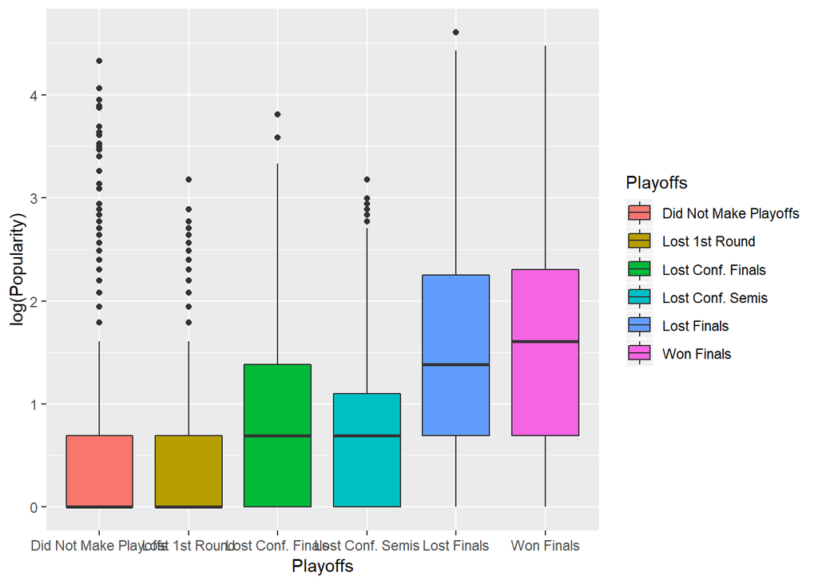

```r
ggplot(NBATeams, aes(y = log(Popularity), x = Playoffs, fill = Playoffs)) + geom_boxplot()
```

```r
#Creating new indicator variable for if team made playoffs
NBATeams <- mutate(NBATeams, IndPlayoffs = ifelse(Playoffs == "Did Not Make Playoffs", "No Playoffs", "Playoffs"))

POIndAov <- lm(Popularity~IndPlayoffs, data=NBATeams)
anova(POIndAov)
```

|  | Df | Sum Sq | Mean Sq | F value | Pr(>F) |
| --- | --- | --- | --- | --- | --- |
| IndPlayoffs | 1 | 2306.994 | 2306.99383 | 97.44494 | 8.586347e-23 |
| Residuals | 5458 | 129217.302 | 23.67484 | NA | NA |

- statistical tests for pop. disc. differences for:
- PO vs not
- W.L.
- more categories - didn’t make POs vs. 1st round etc
- Bandwagon metrics correlate to:
- overall popularity of team
- overall success of team
- other confounders
- Incorporating other datasets

```r
names(bw_Overall) <- c("Team", "PO_diff", "NP_diff", "Bandwagon")

NBATeams <- NBATeams %>% left_join(bw_Overall)
```

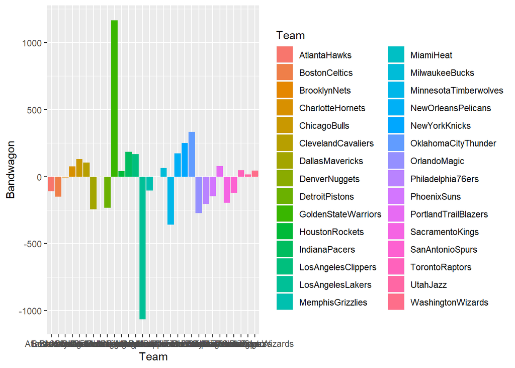

```r
ggplot(NBATeams, aes(x = Team, y = Bandwagon, fill = Team)) + geom_col()
```